# Exploracion de los datos en Egatur.csv

SandradelaFuente

30 de mayo de 2017

# 1 Se establece el directorio de trabajo y las librerías necesarias

library(plyr)  
library(dplyr)  
library(ggplot2)  
library(reshape2)  
library(data.table)

# 2 Exploración de los datos

En este script del TFM, se va a hacer una exploración y transformación de los datos obtenidos del INE para poder plantear una solución, a partir de los mismos, para adecuarlos al problema de modelado que se quiere resolver.

En esta fase se procede, a partir del fichero csv generado en la etapa anterior “data_Cleaning”, a la generación de nuevos registros o valores transformados de atributos existentes, si fuera necesario, en función de los requerimientos para preparar la entrada a las herramientas de modelado.

Cabe recordar que los datos son la representación simbólica (numérica, alfabética,…) de un atributo o variable cuantitativa o cualitativa.

Se procede a dar formato a los datos, estas transformaciones se refieren a modificaciones sintácticas que se hacen sobre ellos, sin alterar su significado pero que pueden ser requeridas por la herramienta de modelado a utilizar.

Puede que haya requisitos en el orden de los atributos o que los registros estén ordenados según el atributo resultado, mediante la evaluación de la información disponible y refinar la pregunta inicial para evitar resultados ambiguos, sesgos o detectar la necesidad de recopilar nuevos datos.

El período de tiempo que se va a utilizar en el TFM, será desde Octubre del 2015 hasta Abril del 2017 (19 meses).

La variable que identifica de manera única cada registro es A0_1.

Para estimar el gasto turístico debe utilizarse la variable ‘gastototal’ multiplicada por el factor de elevación de cada registro (‘Factor_Egatur’).

El gasto medio por persona, se obtendrá como el cociente del gasto turístico entre los turistas, calculados sumando la variable ‘Factor_Egatur’.

La estimación de las pernoctaciones, resultante de multiplicar la variable ‘A13’ por ‘Factor_Egatur’, se utiliza como denominador del gasto medio diario, siendo el numerador el gasto turístico.

Además se utiliza en la estimación de la duración media del viaje, dividiendo los turistas entre las pernoctaciones estimadas.

El fichero PaisesE.csv se relacionan los códigos de cada país, con el nombre del País de residencia habitual del turista.

El fichero CCAAE.csv contiene los códigos de las CCAA y su nombre correspondiente como destino principal del viaje.

```r
dsEgatur <- read.table("../data_cleaning_02/Egatur.csv", header = T, sep = "," , fileEncoding ="utf-8")

head(dsEgatur)
```

```
##               Id Tipo_Viajero Via_Salida Pais Destino_CCAA Pernoctaciones
## 1 0115EVA0000106            2          2   14           13              4
## 2 0115EVA0000142            2          2   14           13             18
## 3 0115EVA0000872            2          2   14           13             19
## 4 0115EVA0001326            2          2   14            9             13
## 5 0115EVA0001394            2          2    4            1              7
## 6 0115EVA0001395            2          2    4            1             12
##   Alojamiento Motivo Paquete_Turistico Gasto_Total  Viajeros Mes Anyo
## 1           1      1                 6    1464.609 188.80330   1 2017
## 2           3      3                 6    1690.454  96.94589   1 2017
## 3           3      3                 6    1890.817  96.94589   1 2017
## 4           3      3                 6    1671.538  87.97956   1 2017
## 5           1      1                 6    1009.927  93.57565   1 2017
## 6           1      1                 1    1602.032  75.96992   1 2017
```

```r
df_Paises <- read.table("../data_cleaning_02/PaisesE.csv", header = T, sep = ";",   fileEncoding="utf-8")
df_Paises
```

```
##    Pais           Nombre
## 1     1         Alemania
## 2     2          Bélgica
## 3     3          Francia
## 4     4          Irlanda
## 5     5           Italia
## 6     6     Países Bajos
## 7     7         Portugal
## 8     8      Reino Unido
## 9     9           Suiza
## 10   10            Rusia
## 11   11  Países Nórdicos
## 12   12  Resto de Europa
## 13   13             EEUU
## 14   14 Resto de América
## 15   15 Resto del mundo
```

```r
df_CCAA <- read.table("../data_cleaning_02/CCAAE.csv", header = T, sep = ";",  fileEncoding="utf-8")
df_CCAA
```

```
##    Codigo                    CCAA
## 1       1               Andalucía
## 2       2                  Aragón
## 3       3 Principado de Asturias
## 4       4               Baleares
## 5       5               Canarias
## 6       6              Cantabria
## 7       7         Castilla y León
## 8       8     Castilla La Mancha
## 9       9                Cataluña
## 10     10         Com.Valenciana
## 11     11           Extremadura
## 12     12               Galicia
## 13     13            Com.Madrid
## 14     14      Región de Murcia
## 15     15            C.F.Navarra
## 16     16             País Vasco
## 17     17               La Rioja
## 18     18                   Ceuta
## 19     19                 Melilla
```

# 3 Formateo de los datos

Se formatea los datos a los tipos adecuados: 1. Tipos numéricos (Viajeros, pernoctaciones y gasto_total) 2. Tipos alfanuméricos (Id) 3. Tipos Categóricos

```r
dsEgatur$Id<-as.character(dsEgatur$Id)

dsEgatur$Viajeros<-as.numeric(dsEgatur$Viajeros)
dsEgatur$Gasto_Total<-as.numeric(dsEgatur$Gasto_Total)
dsEgatur$Gasto_Real <- as.numeric(0)
dsEgatur$Pernoctaciones<-as.numeric(dsEgatur$Pernoctaciones)
dsEgatur$Pernoctaciones_Real <- as.numeric(0)


dsEgatur$Tipo_Viajero<-as.factor(dsEgatur$Tipo_Viajero)
dsEgatur$Via_Salida<-as.factor(dsEgatur$Via_Salida)
dsEgatur$Pais<-as.factor(dsEgatur$Pais)
dsEgatur$Destino_CCAA<-as.factor(dsEgatur$Destino_CCAA)

dsEgatur$Alojamiento<-as.factor(dsEgatur$Alojamiento)
dsEgatur$Motivo<-as.factor(dsEgatur$Motivo)
dsEgatur$Paquete_Turistico<-as.factor(dsEgatur$Paquete_Turistico)
dsEgatur$Mes<-as.factor(dsEgatur$Mes)
dsEgatur$Anyo<-as.factor(dsEgatur$Anyo)

head(dsEgatur)
```

```
##               Id Tipo_Viajero Via_Salida Pais Destino_CCAA Pernoctaciones
## 1 0115EVA0000106            2          2   14           13              4
## 2 0115EVA0000142            2          2   14           13             18
## 3 0115EVA0000872            2          2   14           13             19
## 4 0115EVA0001326            2          2   14            9             13
## 5 0115EVA0001394            2          2    4            1              7
## 6 0115EVA0001395            2          2    4            1             12
##   Alojamiento Motivo Paquete_Turistico Gasto_Total  Viajeros Mes Anyo
## 1           1      1                 6    1464.609 188.80330   1 2017
## 2           3      3                 6    1690.454  96.94589   1 2017
## 3           3      3                 6    1890.817  96.94589   1 2017
## 4           3      3                 6    1671.538  87.97956   1 2017
## 5           1      1                 6    1009.927  93.57565   1 2017
## 6           1      1                 1    1602.032  75.96992   1 2017
##   Gasto_Real Pernoctaciones_Real
## 1          0                   0
## 2          0                   0
## 3          0                   0
## 4          0                   0
## 5          0                   0
## 6          0                   0
```

```r
df_Paises$Pais<-as.factor(df_Paises$Pais)

df_CCAA$Codigo<-as.factor(df_CCAA$Codigo)
colnames(df_CCAA)[colnames(df_CCAA)=="Codigo"] <- "Destino_CCAA"
```

# 4 Revisión de los datos del fichero csv

En este bloque se realiza una revisión del dataset.

```r
head(dsEgatur)
```

```
##               Id Tipo_Viajero Via_Salida Pais Destino_CCAA Pernoctaciones
## 1 0115EVA0000106            2          2   14           13              4
## 2 0115EVA0000142            2          2   14           13             18
## 3 0115EVA0000872            2          2   14           13             19
## 4 0115EVA0001326            2          2   14            9             13
## 5 0115EVA0001394            2          2    4            1              7
## 6 0115EVA0001395            2          2    4            1             12
##   Alojamiento Motivo Paquete_Turistico Gasto_Total  Viajeros Mes Anyo
## 1           1      1                 6    1464.609 188.80330   1 2017
## 2           3      3                 6    1690.454  96.94589   1 2017
## 3           3      3                 6    1890.817  96.94589   1 2017
## 4           3      3                 6    1671.538  87.97956   1 2017
## 5           1      1                 6    1009.927  93.57565   1 2017
## 6           1      1                 1    1602.032  75.96992   1 2017
##   Gasto_Real Pernoctaciones_Real
## 1          0                   0
## 2          0                   0
## 3          0                   0
## 4          0                   0
## 5          0                   0
## 6          0                   0
```

```r
tail(dsEgatur)
```

```
##                    Id Tipo_Viajero Via_Salida Pais Destino_CCAA
## 135144 20151200037718            2          1    8           11
## 135145 20151200037720            8          1   11           10
## 135146 20151200037721            8          1    3            7
## 135147 20151200037722            2          1    8            1
## 135148 20151200037723            2          1    3           16
## 135149 20151200037725            8          1    8            1
##        Pernoctaciones Alojamiento Motivo Paquete_Turistico Gasto_Total
## 135144             12           3      3                 6    304.9839
## 135145              6           3      3                 6    569.7706
## 135146              1           1      3                 6    172.9911
## 135147             35           3      1                 6    994.0879
## 135148              3           2      1                 6    188.8411
## 135149              4           3      1                 6    313.1718
##         Viajeros Mes Anyo Gasto_Real Pernoctaciones_Real
## 135144  692.9668  12 2015          0                   0
## 135145  375.3214  12 2015          0                   0
## 135146 1297.4688  12 2015          0                   0
## 135147 1867.1547  12 2015          0                   0
## 135148 4144.2436  12 2015          0                   0
## 135149 1867.1547  12 2015          0                   0
```

```r
nrow(dsEgatur)
```

```
## [1] 135149
```

```r
ncol(dsEgatur)
```

```
## [1] 15
```

```r
str(dsEgatur)
```

```
## 'data.frame':    135149 obs. of  15 variables:
##  $ Id                 : chr  "0115EVA0000106" "0115EVA0000142" "0115EVA0000872" "0115EVA0001326" ...
##  $ Tipo_Viajero       : Factor w/ 2 levels "2","8": 1 1 1 1 1 1 1 1 1 1 ...
##  $ Via_Salida         : Factor w/ 4 levels "1","2","3","4": 2 2 2 2 2 2 2 2 2 2 ...
##  $ Pais               : Factor w/ 15 levels "1","2","3","4",..: 14 14 14 14 4 4 4 4 4 4 ...
##  $ Destino_CCAA       : Factor w/ 19 levels "1","2","3","4",..: 13 13 13 9 1 1 1 1 1 1 ...
##  $ Pernoctaciones     : num  4 18 19 13 7 12 21 42 21 13 ...
##  $ Alojamiento        : Factor w/ 3 levels "1","2","3": 1 3 3 3 1 1 3 2 2 3 ...
##  $ Motivo             : Factor w/ 3 levels "1","2","3": 1 3 3 3 1 1 3 1 1 1 ...
##  $ Paquete_Turistico  : Factor w/ 2 levels "1","6": 2 2 2 2 2 1 2 2 2 2 ...
##  $ Gasto_Total        : num  1465 1690 1891 1672 1010 ...
##  $ Viajeros           : num  188.8 96.9 96.9 88 93.6 ...
##  $ Mes                : Factor w/ 12 levels "1","2","3","4",..: 1 1 1 1 1 1 1 1 1 1 ...
##  $ Anyo               : Factor w/ 3 levels "2015","2016",..: 3 3 3 3 3 3 3 3 3 3 ...
##  $ Gasto_Real         : num  0 0 0 0 0 0 0 0 0 0 ...
##  $ Pernoctaciones_Real: num  0 0 0 0 0 0 0 0 0 0 ...
```

Se procede a comparar los datos obtenidos del dataset, con la documentacion del INE (fichero /data_01/Egatur/disreg_egatur16.xlsx en ), para detectar posibles datos nulos, outliers o datos erróneos.

# 5 Valores perdidos (missing values)

El tratamiento de los datos es fundamental para la correcta interpretación de un análisis, los valores perdidos son aquellos que simplemente se ha perdido algún dato y no sabemos qué valor toma, se representa por el código: NA (Not available).

Hay muchas funciones para identificar estos valores, la más usada es is.na().

Para el fichero Egatur se han detectado 4 valores NA en la columna de Viajeros.

```r
sapply(dsEgatur,function(x) sum(is.na(x)))
```

```
##                  Id        Tipo_Viajero          Via_Salida
##                   0                   0                   0
##                Pais        Destino_CCAA      Pernoctaciones
##                   0                   0                   0
##         Alojamiento              Motivo   Paquete_Turistico
##                   0                   0                   0
##         Gasto_Total            Viajeros                 Mes
##                   0                   4                   0
##                Anyo          Gasto_Real Pernoctaciones_Real
##                   0                   0                   0
```

Por lo tanto para tener problemas en los cálculos de los datos, se van a sustituir por un 0 los NA (esta variable es numérica).

```r
dsEgatur$Viajeros[is.na(dsEgatur$Viajeros)]<-0

sapply(dsEgatur,function(x) sum(is.na(x)))
```

```
##                  Id        Tipo_Viajero          Via_Salida
##                   0                   0                   0
##                Pais        Destino_CCAA      Pernoctaciones
##                   0                   0                   0
##         Alojamiento              Motivo   Paquete_Turistico
##                   0                   0                   0
##         Gasto_Total            Viajeros                 Mes
##                   0                   0                   0
##                Anyo          Gasto_Real Pernoctaciones_Real
##                   0                   0                   0
```

En cambio no existen valores NaN en el dataset.

```r
sapply(dsEgatur,function(x) sum(is.nan(x)))
```

```
##                  Id        Tipo_Viajero          Via_Salida
##                   0                   0                   0
##                Pais        Destino_CCAA      Pernoctaciones
##                   0                   0                   0
##         Alojamiento              Motivo   Paquete_Turistico
##                   0                   0                   0
##         Gasto_Total            Viajeros                 Mes
##                   0                   0                   0
##                Anyo          Gasto_Real Pernoctaciones_Real
##                   0                   0                   0
```

# 6 Análisis descriptivo de los datos

```r
summary(dsEgatur)
```

```
##       Id            Tipo_Viajero Via_Salida      Pais
##  Length:135149      2:128286     1: 15394   8      :26398
##  Class :character   8:  6863     2:112641   3      :18043
##  Mode  :character                3:  5280   1      :17560
##                                  4:  1834   5      : 9918
##                                             11     : 9033
##                                             15     : 8818
##                                             (Other):45379
##   Destino_CCAA   Pernoctaciones    Alojamiento Motivo    Paquete_Turistico
##  9      :32491   Min.   :  1.000   1:74833     1:91646   1: 25399
##  4      :19824   1st Qu.:  4.000   2:14621     2:15669   6:109750
##  10     :19248   Median :  7.000   3:45695     3:27834
##  5      :16664   Mean   :  9.326
##  1      :15599   3rd Qu.: 10.000
##  13     :13330   Max.   :300.000
##  (Other):17993
##   Gasto_Total          Viajeros            Mes          Anyo
##  Min.   :   18.27   Min.   :    0.0   4      :14769   2015:20417
##  1st Qu.:  579.18   1st Qu.:  196.6   11     :14195   2016:87864
##  Median :  881.62   Median :  465.1   3      :13805   2017:26868
##  Mean   : 1124.00   Mean   :  807.0   12     :13653
##  3rd Qu.: 1278.39   3rd Qu.: 1038.0   10     :13474
##  Max.   :40585.24   Max.   :40566.3   1      :12832
##                                       (Other):52421
##    Gasto_Real Pernoctaciones_Real
##  Min.   :0    Min.   :0
##  1st Qu.:0    1st Qu.:0
##  Median :0    Median :0
##  Mean   :0    Mean   :0
##  3rd Qu.:0    3rd Qu.:0
##  Max.   :0    Max.   :0
##
```

Para estimar el gasto turístico debe utilizarse la variable ‘gasto_total’ multiplicada por el factor de elevación de cada registro (‘Viajeros’).

La estimación real de las pernoctaciones, se obtiene multiplicando la variable ‘Pernoctaciones’ por ‘Viajeros’.

```r
dsEgatur$Gasto_Real <-  as.numeric(dsEgatur$Viajeros * dsEgatur$Gasto_Total)

dsEgatur$Pernoctaciones_Real <- as.numeric(dsEgatur$Pernoctaciones * dsEgatur$Viajeros)

head(dsEgatur)
```

```
##               Id Tipo_Viajero Via_Salida Pais Destino_CCAA Pernoctaciones
## 1 0115EVA0000106            2          2   14           13              4
## 2 0115EVA0000142            2          2   14           13             18
## 3 0115EVA0000872            2          2   14           13             19
## 4 0115EVA0001326            2          2   14            9             13
## 5 0115EVA0001394            2          2    4            1              7
## 6 0115EVA0001395            2          2    4            1             12
##   Alojamiento Motivo Paquete_Turistico Gasto_Total  Viajeros Mes Anyo
## 1           1      1                 6    1464.609 188.80330   1 2017
## 2           3      3                 6    1690.454  96.94589   1 2017
## 3           3      3                 6    1890.817  96.94589   1 2017
## 4           3      3                 6    1671.538  87.97956   1 2017
## 5           1      1                 6    1009.927  93.57565   1 2017
## 6           1      1                 1    1602.032  75.96992   1 2017
##   Gasto_Real Pernoctaciones_Real
## 1  276522.97            755.2132
## 2  163882.61           1745.0261
## 3  183306.96           1841.9720
## 4  147061.19           1143.7343
## 5   94504.58            655.0295
## 6  121706.27            911.6390
```

```r
egaturRFM <- dsEgatur[c(1,4,5,10,12,13)]

head(egaturRFM)
```

```
##               Id Pais Destino_CCAA Gasto_Total Mes Anyo
## 1 0115EVA0000106   14           13    1464.609   1 2017
## 2 0115EVA0000142   14           13    1690.454   1 2017
## 3 0115EVA0000872   14           13    1890.817   1 2017
## 4 0115EVA0001326   14            9    1671.538   1 2017
## 5 0115EVA0001394    4            1    1009.927   1 2017
## 6 0115EVA0001395    4            1    1602.032   1 2017
```

Los turistas que vienen a España durante el periodo Octubre 2015 a Abril 2017 se gastan 111.760.512.068 euros.

```r
totalG = summarize(dsEgatur, totalG = sum(dsEgatur$Gasto_Real, na.rm = T))
totalG
```

```
##         totalG
## 1 111760512068
```

Se calcula el número total de turistas que vienen a España según los datos de Egatur 109.072.379 de turistas.

```r
totalT= summarize(dsEgatur, totalT = sum(dsEgatur$Viajeros, na.rm = T))
totalT
```

```
##      totalT
## 1 109072379
```

El gasto medio por persona, se obtendrá como el cociente del gasto turístico entre los turistas, calculados sumando la variable ‘Viajeros’ –> 1024.645 euros.

```r
gasto_Medio <-  (totalG[,"totalG"]/totalT[,"totalT"])
gasto_Medio
```

```
## [1] 1024.645
```

La estimación de las pernoctaciones, resultante de multiplicar la variable ‘A13’ por ‘Factor_Egatur’, se utiliza como denominador del gasto medio diario, siendo el numerador el gasto turístico.

```r
totalP= summarize(dsEgatur, totalP = sum(dsEgatur$Pernoctaciones_Real, na.rm = T))
totalP
```

```
##      totalP
## 1 861891254
```

Número total de pernoctaciones 861.891.254, cuyo gasto medio diario es 129.6689 euros.

```r
gasto_Medio_Diario = totalG[,"totalG"] / totalP[,"totalP"]
gasto_Medio_Diario
```

```
## [1] 129.6689
```

Además se utiliza en la estimación de la duración media del viaje, dividiendo los turistas entre las pernoctaciones estimadas, siendo para los datos de este TFM 0.12655 noches

```r
duracion_Media = totalT[,"totalT"]/totalP[,"totalP"]
duracion_Media
```

```
## [1] 0.12655
```

Gasto de turistas internacionales por país de residencia y porcentaje respecto al total.

Se detecta que los turistas que más gastan son los ingleses (20%), a continuación los alemanes (14%) y en tercer lugar los extranjeros del resto del mundo (11%).

```r
res <- ddply(dsEgatur, .(Pais), summarize, Total = sum(Gasto_Real))



res2 <- ddply(res, .(Pais, Total), transform, pct= 100 * Total /totalG[,"totalG"])
res2
```

```
##    Pais       Total       pct
## 1     1 15843472881 14.176271
## 2     2  3203772788  2.866641
## 3     3  9631546210  8.618023
## 4     4  2464203457  2.204896
## 5     5  4264472783  3.815724
## 6     6  4906039952  4.389779
## 7     7  1191179801  1.065832
## 8     8 22742846749 20.349626
## 9     9  2346621498  2.099687
## 10   10  2160237825  1.932917
## 11   11  9591722167  8.582389
## 12   12  6925018683  6.196302
## 13   13  5647142331  5.052896
## 14   14  8069972068  7.220772
## 15   15 12772262877 11.428243
```

```r
df_merge  <- inner_join(res2,df_Paises)
df_merge<-df_merge[order(df_merge$Total,decreasing=T),]
df_merge
```

```
##    Pais       Total       pct           Nombre
## 8     8 22742846749 20.349626      Reino Unido
## 1     1 15843472881 14.176271         Alemania
## 15   15 12772262877 11.428243 Resto del mundo
## 3     3  9631546210  8.618023          Francia
## 11   11  9591722167  8.582389  Países Nórdicos
## 14   14  8069972068  7.220772 Resto de América
## 12   12  6925018683  6.196302  Resto de Europa
## 13   13  5647142331  5.052896             EEUU
## 6     6  4906039952  4.389779     Países Bajos
## 5     5  4264472783  3.815724           Italia
## 2     2  3203772788  2.866641          Bélgica
## 4     4  2464203457  2.204896          Irlanda
## 9     9  2346621498  2.099687           Suiza
## 10   10  2160237825  1.932917            Rusia
## 7     7  1191179801  1.065832         Portugal
```

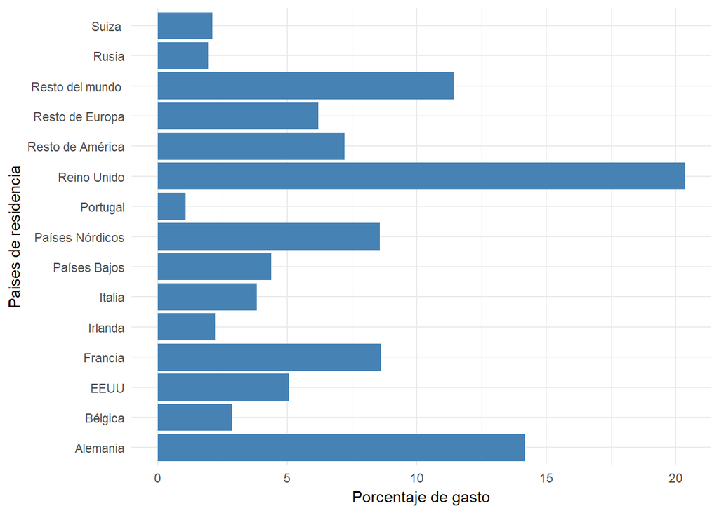

```r
ggplot(data=df_merge, aes(y=pct, x=Nombre)) +
  geom_bar(stat="identity", fill="steelblue",  width=0.9) +
   labs(x = "Paises de residencia", y = "Porcentaje de gasto")+
  coord_flip() +
  theme_minimal()
```

Gasto por Comunidades Autónomas y porcentaje respecto al total.

Cataluña es el principal destino principal de los turistas con un gasto realizado de 24.949.885.499 euros durante el periodo de estudio, lo que representa el 22 % del total.

Canarias (21%) y Andalucía (14%) son las siguientes Comunidades Autónomas con más gasto realizado en España.

```r
res3 <- ddply(dsEgatur, .(Destino_CCAA), summarize, Total = sum(Gasto_Real))

res4 <- ddply(res3, .(Destino_CCAA, Total), transform, pct= 100 * Total / totalG[,"totalG"])
res4
```

```
##    Destino_CCAA       Total          pct
## 1             1 16515481698 14.777564448
## 2             2   623848325  0.558201026
## 3             3   472228692  0.422536264
## 4             4 15602271483 13.960450963
## 5             5 24349914959 21.787583565
## 6             6   584524344  0.523015091
## 7             7   799816859  0.715652464
## 8             8   230383890  0.206140690
## 9             9 24949885499 22.324419455
## 10           10 10543023038  9.433585121
## 11           11   145208484  0.129928256
## 12           12  1167913825  1.045014741
## 13           13 11610373959 10.388619150
## 14           14  1331062986  1.190995783
## 15           15   271658604  0.243072083
## 16           16  2417471595  2.163082067
## 17           17   139120045  0.124480501
## 18           18     1910048  0.001709054
## 19           19     4413736  0.003949280
```

```r
df_mergeCCAA  <- inner_join(res4,df_CCAA)
df_mergeCCAA <- df_mergeCCAA[order(df_mergeCCAA$Total,decreasing=T),]

df_mergeCCAA
```

```
##    Destino_CCAA       Total          pct                    CCAA
## 9             9 24949885499 22.324419455                Cataluña
## 5             5 24349914959 21.787583565               Canarias
## 1             1 16515481698 14.777564448               Andalucía
## 4             4 15602271483 13.960450963               Baleares
## 13           13 11610373959 10.388619150            Com.Madrid
## 10           10 10543023038  9.433585121         Com.Valenciana
## 16           16  2417471595  2.163082067             País Vasco
## 14           14  1331062986  1.190995783      Región de Murcia
## 12           12  1167913825  1.045014741               Galicia
## 7             7   799816859  0.715652464         Castilla y León
## 2             2   623848325  0.558201026                  Aragón
## 6             6   584524344  0.523015091              Cantabria
## 3             3   472228692  0.422536264 Principado de Asturias
## 15           15   271658604  0.243072083            C.F.Navarra
## 8             8   230383890  0.206140690     Castilla La Mancha
## 11           11   145208484  0.129928256           Extremadura
## 17           17   139120045  0.124480501               La Rioja
## 19           19     4413736  0.003949280                 Melilla
## 18           18     1910048  0.001709054                   Ceuta
```

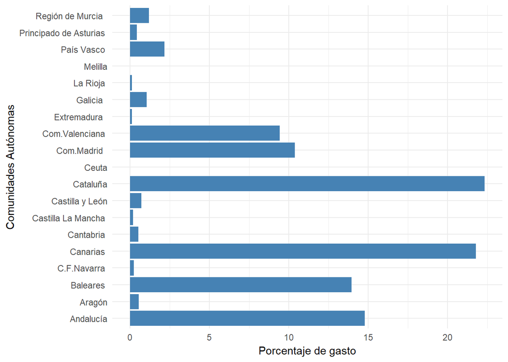

```r
ggplot(data=df_mergeCCAA, aes(y=pct, x=CCAA)) +
  geom_bar(stat="identity", fill="steelblue",  width=0.9) +
   labs(x = "Comunidades Autónomas", y = "Porcentaje de gasto")+
  coord_flip() +
  theme_minimal()
```

El mes con mayor gasto económico de los turistas que visitaron España, fue Agosto del 2016 con 10.354.421.287 euros.

```r
Ft_dt <- data.table(dsEgatur)

Ft_dt2 <- Ft_dt[, list(Gasto_Real = sum(Gasto_Real)), by = c("Anyo","Mes")]

Ft_dt2 <- arrange(Ft_dt2,desc(Gasto_Real))

head(Ft_dt2,10)
```

```
##    Anyo Mes  Gasto_Real
## 1  2016   8 10354421287
## 2  2016   7 10256958301
## 3  2016   9  8327621258
## 4  2016   6  7871180356
## 5  2016  10  7304827609
## 6  2016   5  6913672786
## 7  2017   4  6738949573
## 8  2015  10  6280629641
## 9  2016   4  5646796380
## 10 2017   3  5098314421
```

Se obtiene el gasto de turistas internacionales por meses y Destino_CCAA, variación temporal Octubre 2015 a Abril 2017.

De los datos se obtiene que el mes de Julio de 2016 hubo el mayor gasto turístico de los viajeros extranjeros en Baleares y en segunda posición Cataluña.

```r
Ft_dt3 <- Ft_dt[, list(Gasto_Real = sum(Gasto_Real)), by = c("Anyo","Mes", "Destino_CCAA")]

Ft_dt3 <- arrange(Ft_dt3,desc(Gasto_Real))

head(Ft_dt3,10)
```

```
##    Anyo Mes Destino_CCAA Gasto_Real
## 1  2016   7            4 2590942654
## 2  2016   7            9 2527615012
## 3  2016   8            4 2505299480
## 4  2016   8            9 2398524551
## 5  2016   9            9 2038055016
## 6  2016   6            4 1864357176
## 7  2016   9            4 1823457766
## 8  2016   6            9 1745515694
## 9  2016   5            9 1540554358
## 10 2017   3            5 1511355361
```

```r
tail(Ft_dt3,10)
```

```
##     Anyo Mes Destino_CCAA Gasto_Real
## 328 2016   1           18  392477.75
## 329 2016  10           18  287456.95
## 330 2015  10           18  272518.54
## 331 2016   9           19  262822.20
## 332 2016  11           19  257959.17
## 333 2016   7           19  217036.97
## 334 2017   1           19   62858.75
## 335 2016   5           18   54500.01
## 336 2017   2           19   53472.83
## 337 2016   6           19   40468.75
```

Los ingleses son los extranjeros que más gastaron en España, durante el mes de Agosto del 2016 -> 2.312.129.733 euros

```r
Ft_dt4 <- Ft_dt[, list(Gasto_Real = sum(Gasto_Real)), by = c("Anyo","Mes", "Pais")]

Ft_dt4 <- arrange(Ft_dt4,desc(Gasto_Real))

head(Ft_dt4,10)
```

```
##    Anyo Mes Pais Gasto_Real
## 1  2016   8    8 2312129733
## 2  2016   7    8 2227733097
## 3  2016   9    8 1832757521
## 4  2016   6    8 1807764464
## 5  2016   5    8 1486481589
## 6  2016  10    8 1461093522
## 7  2016   8    1 1442614182
## 8  2016   8    3 1414642821
## 9  2015  10    8 1336413822
## 10 2016   7    1 1309078887
```

```r
tail(Ft_dt4,10)
```

```
##     Anyo Mes Pais Gasto_Real
## 276 2016   4    7   48219280
## 277 2016   2    7   43392953
## 278 2016  11    7   43078893
## 279 2016  12    7   42772377
## 280 2016   1    7   39238326
## 281 2017   2    7   38882097
## 282 2017   3    7   38288026
## 283 2015  11    7   37989711
## 284 2015  12    7   37577568
## 285 2017   1    7   31497325
```

Se genera un fichero en formato csv con los datos del dataset.

```r
write.csv(egaturRFM,file="egaturRFM.csv",row.names = FALSE )
write.csv(Ft_dt4,file="gasto_fec_pais.csv",row.names = FALSE )
write.csv(Ft_dt3,file="gasto_fec_ccaa.csv",row.names = FALSE )
write.csv(dsEgatur,file="dsEgatur_Final.csv",row.names = FALSE )
```